# regridding_interactive_lecture

## Source Code

**To use the interactive sliders, run the cell below pressing** **`Shift`** + **`Enter`** **and scroll down to interactive section**

```python
import numpy as np
import ipywidgets as widgets
import matplotlib.pyplot as plt
import xarray as xr
from Uncertainty_Functions import *
```

###### To view as a slide show run:

`jupyter nbconvert regridding_interactive_lecture.ipynb --to slides --post serve`

```python
ds = xr.open_dataset('avhrr_sample_easyFCDR.nc')
t4 = np.array(ds.Ch4)
uit4 = np.array(ds.u_independent_Ch4)
ust4 = np.array(ds.u_structured_Ch4)
uct4 = np.array(ds.u_common_Ch4)
uncertainties = np.array([uit4,uct4,ust4])
cmap = "gnuplot2"
Titlestart = "Uncertainty from \n"
Names = np.array(["Independent","Common","Structured"])
cbar_range = np.array([0,0.16])
N_values = np.arange(15)
x_val= np.linspace(1,15,100)
```

# Interactive Lecture: Uncertainties in Gridding

In this exercise we will compare the extent to which the different types of uncertainties contribute to the combinded standard uncertainty for gridding processes.

| It is structured as follows: |
| --- |
| 1. Define Gridding |
| 2.1. Properties of Independent Uncertainties |
| 2.2. Properties of Common Uncertainties |
| 3. Interactive comparison using real data |
| 4. Extension Exercises |

## 1. The Gridding Process

A simple process of gridding a set of pixels, ${z_i}$, is the following,

$\langle z \rangle = \frac{1}{N} \sum_i^N z_i$

where:

- $u_{\mathrm{ind.}}^2(\langle z \rangle)$ - is the uncertainty of the grid cell due to independent error effects
- $u_{\mathrm{com.}}^2(\langle z \rangle)$ - is the uncertainty of the grid cell due to common error effects
- Note that uncertainty due to structured error effects are omitted

In this exercise we will look at gridding the FIDUCEO easyFCDR AVHRR sample file to a L3 grid, propagating the independent and common uncertainty components through the processing.

## 2. Uncertainties in Gridding

### `i. Independent Uncertainties`

In an image, independent errors therefore arise from random effects operating at the image pixel level, the classic example being detector noise. The uncertainty of the result of an averaging process for these kind of effects is:

$$ u_{\mathrm{ind.}}^2(\langle z \rangle) = \frac{1}{N^2}\sum_i^N u_{\mathrm{ind.}}^2(z_i)$$

Therefore the contribution of the independent uncertainty to the combined uncertainty $u_c(\langle z \rangle )$ will follow the relationship:

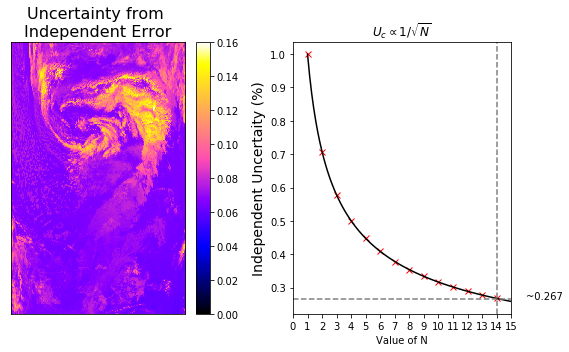

```python
IndependentUFig(N_values,x_val,uncertainties,cbar_range,cmap,Names,Titlestart)
```

### `ii. Common Uncertainties`

Common errors are common between satellite pixels for an entire mission. The uncertainty of the result of an averaging process for these kind of effects is:

$$ u_{\mathrm{com.}}^2(\langle z \rangle) = \frac{1}{N^2}\left [ \sum_i^N u_{\mathrm{com.}}(z_i) \right ]^2 = \langle u_{\mathrm{com.}}(z_i) \rangle^2$$

We find therefore that this type of uncertainty does not reduce with N.

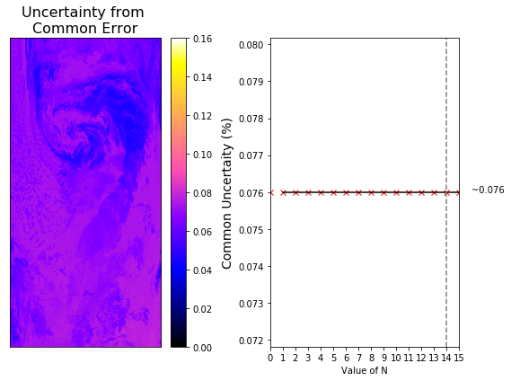

```python
CommonUFig(N_values,x_val,uncertainties,cbar_range,cmap,Names,Titlestart)
```

**Exit Slideshow to show Interactive plots**

## 3. Interactive Comparison Using Real Data

The graphs below illustrate the combination of independent and common uncertainties for a grid cell in the centre of our AVHRR easyFCDR sample data.

The sliders allow you to change:

- The fraction of uncertainty coming from independent and common error sources
- The size of the grid cell
- The X position of the grid cell
- The Y position

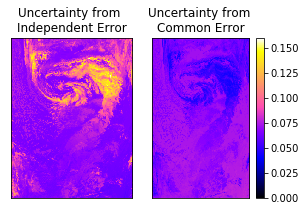

```python
ThreeErrors(uncertainties,cbar_range,cmap,Titlestart,Names,v1=False)
@widgets.interact(Percentage=(0,1,0.1),Size=(2,100,5),X=(0,400,10),Y=(0,700,20))
def P(Percentage,Size,X,Y):
    fig = plt.figure(figsize=(6,8))
    param = Percentage
    Size = Size
    WindowU = []
    ModI = []
    for elem in uncertainties:
        W , Mo = Scan(elem,np.array([Size,Size]),np.array([X,Y]))
        WindowU.append(W)
        ModI.append(Mo)
    WindowU = np.array(WindowU)
    ModI = np.array(ModI)
    Im = np.array([WindowU,ModI])
    BackU = CombinedDa(Im,param,Size,Averaging=False,ShowStructured=False)
    WindowU = CombinedDa(Im,param,Size,Averaging=True,ShowStructured=False)
    plt.imshow(BackU + WindowU,cmap=cmap,vmin=cbar_range[0],vmax=cbar_range[1])
    plt.title("Combined Uncertainties",size=16)
    plt.colorbar(shrink=0.9,aspect=50),#orientation='horizontal')
    plt.tick_params(axis='both', left='off', top='off', right='off', bottom='off', labelleft='off', labeltop='off', labelright='off', labelbottom='off')
```

## 4. Extension Exercises

The interactive plot below shows a zoomed-in version of the previous graph. The idea is to show how both the gridding size and the proportion of common to independent uncertanty play a role in the value for the combined standard uncertainty. Here, the figure axis scale varies with the window size in order to better represent changes to the combined standard uncertainty. The graph on the right plots the value of the combined standard uncertainty and will update everytime there is a change to one of the sliders. Here Slide refers to the side length of the averaging window, such that $N=S^2$. Keep this in mind when observing the *$\frac{1}{\sqrt{N}}$* behaviour , as you will be seeing *$\frac{1}{S}$* behaviour.

```python
window_values = []
@widgets.interact(Percentage=(0,1,0.01),Size=(1,30,1),X=(0,400,10),Y=(0,700,20))
def P(Percentage,Size,X,Y):
    plt.figure(figsize=(10,7))
    cmap = "gnuplot2"
    cbar_range = np.array([0,0.16])
    param = Percentage
    Size = Size
    WindowU = []
    ModI = []
    for elem in uncertainties:
        W , Mo = Scan(elem,np.array([Size,Size]),np.array([X,Y]))
        WindowU.append(W)
        ModI.append(Mo)
    WindowU = np.array(WindowU)
    ModI = np.array(ModI)
    Im = np.array([WindowU,ModI])
    BackU = CombinedDa(Im,param,Size,Averaging=False,ShowStructured=False)
    WindowU = CombinedDa(Im,param,Size,Averaging=True,ShowStructured=False)
    plt.subplot(121)
    if Y-4*Size>0 and X-3*Size>0:
        plt.imshow(BackU[Y-4*Size:Y+4*Size,X-3*Size:X+3*Size]+WindowU[Y-4*Size:Y+4*Size,X-3*Size:X+3*Size],cmap=cmap,vmin=cbar_range[0],vmax=cbar_range[1])
    else:
        plt.imshow(BackU[0:Y+4*Size,0:X+3*Size]+WindowU[0:Y+4*Size,0:X+3*Size],cmap=cmap,vmin=cbar_range[0],vmax=cbar_range[1])
    Windowvalue = WindowU[np.nonzero(WindowU)][0]
    window_values.append(Windowvalue)
    plt.subplot(121)
    plt.colorbar(shrink=0.7)
    plt.tick_params(axis='both', left='off', top='off', right='off', bottom='off', labelleft='off', labeltop='off', labelright='off', labelbottom='off')
    plt.subplot(122)
    plt.yscale('log')
    plt.ylim([0.002,0.11])
    plt.title("Combined Average Uncertainty")
    plt.plot(window_values[len(window_values)-100:],'-.',color='black')
    plt.tight_layout()
    plt.tick_params(axis='both', left='on', top='off', right='off', bottom='off', labelleft='on', labeltop='off', labelright='off', labelbottom='off')
    plt.show()
```

## TO DO:

Below exercises that will test your understanding of how uncertainties combine. When exploring each exercise, think of how the information previously mentioned might explain the changes that you see. Try changing the slider values to investigate how the value of the combined average uncertainty varies as:

1. The combined uncertainty is *purely independent* (Percentage slider == 0) and Size increases slowly from 1 to 20.
2. The combined uncertainty is *purely common* (Percentage slider == 1) and Size increases slowly from 1 to 20.
3. The combined uncertainty is *purely independent* (Percentage slider == 0) at size ~10 and only vary X and Y.
4. The combined uncertainty is *purely common* (Percentage slider == 1) at size ~10 and only vary X and Y.
5. The combined uncertainty is split 50/50 between independent and common, at varying sizes from 1 to 15 and varying X and Y.
6. The combined uncertainty is split 90/10 between independent and common (Percentage slider == 0.1), at varying sizes from 1 to 15 and varying X.
7. What other properties can you observe that you might expect from the expected behaviour? What behaviour do you observe that you did not expect?

You can insert a specific value for the sliders by clicking on the number. To see a clear representation of the *$\frac{1}{\sqrt{N}}$* behaviour input the following parameters:

1. Percentage = 0.06
2. Size = Increase slowly from 1 $\rightarrow$ 30
3. X = 150
4. Y = 280

**NB: For faster performance calculating the combined average uncertainty, click on `Kernel` $\rightarrow$ `Interrupt` and re-run the cell. It is recommended to do this between each exercise.**